# Multi-pedon workflow: fitting retention curves at scale

## Overview

In landscape-scale soil hydrology studies, Van Genuchten parameters must be fitted independently at each sampling location (pedon). With hundreds or thousands of pedons, sequential NLS fitting becomes a throughput bottleneck. This vignette demonstrates:

1. Constructing a realistic multi-pedon dataset from synthetic field observations.
2. Running `fit_swrc()` sequentially and in parallel with `workers = parallel::detectCores(logical = FALSE)`.
3. Mapping the fitted saturated water content (θ_s) and shape parameter (*n*) back to pedon locations.

## Setup

```r
library(tidysoilwater)
library(dplyr)
library(ggplot2)
```

## 1 Generate a synthetic pedon network

```r
set.seed(2047)

# Van Genuchten parameters from Van Genuchten (1980, Table 1)
# Van Genuchten parameters for four textures with n > 1.5 — these are
# well-conditioned for NLS fitting.  Soils with n close to 1 (e.g. clay,
# silty clay loam) have flat retention curves that make NLS poorly
# conditioned; a real workflow would require more robust starting values
# or a Bayesian approach for those classes.
vg_reference <- tribble(
  ~texture,      ~theta_r, ~theta_s, ~alpha,  ~n,
  "sand",        0.045,    0.430,    0.145,   2.68,
  "loamy sand",  0.057,    0.410,    0.124,   2.28,
  "sandy loam",  0.065,    0.410,    0.075,   1.89,
  "loam",        0.078,    0.430,    0.036,   1.56
)

# 200 pedons on a 20 × 10 spatial grid (arbitrary units)
pedons <- expand.grid(x = seq(1, 20), y = seq(1, 10)) |>
  as_tibble() |>
  mutate(
    pedon_id = row_number(),
    # Texture follows a simple catena: coarser soils in the west,
    # finer (loam) in the east — a typical hillslope pattern
    texture = case_when(
      x <= 5  ~ "sand",
      x <= 10 ~ "loamy sand",
      x <= 15 ~ "sandy loam",
      TRUE    ~ "loam"
    )
  ) |>
  left_join(vg_reference, by = "texture")

glimpse(pedons)
```

```
#> Rows: 200
#> Columns: 8
#> $ x        <int> 1, 2, 3, 4, 5, 6, 7, 8, 9, 10, 11, 12, 13, 14, 15…
#> $ y        <int> 1, 1, 1, 1, 1, 1, 1, 1, 1, 1, 1, 1, 1, 1, 1, 1, 1…
#> $ pedon_id <int> 1, 2, 3, 4, 5, 6, 7, 8, 9, 10, 11, 12, 13, 14, 15…
#> $ texture  <chr> "sand", "sand", "sand", "sand", "sand", "loamy sa…
#> $ theta_r  <dbl> 0.045, 0.045, 0.045, 0.045, 0.045, 0.057, 0.057, …
#> $ theta_s  <dbl> 0.43, 0.43, 0.43, 0.43, 0.43, 0.41, 0.41, 0.41, 0…
#> $ alpha    <dbl> 0.145, 0.145, 0.145, 0.145, 0.145, 0.124, 0.124, …
#> $ n        <dbl> 2.68, 2.68, 2.68, 2.68, 2.68, 2.28, 2.28, 2.28, 2…
```

## 2 Simulate field observations

Laboratory or field tensiometer measurements typically cover 8–12 pressure heads from saturation (h = 0) to permanent wilting point (h = 15 000 cm). We generate synthetic θ(h) observations by evaluating the VG model at each pedon’s true parameters, then adding realistic measurement noise (σ = 0.005 m³/m³).

```r
h_obs <- c(0, 1, 5, 10, 50, 100, 300, 500, 1000, 3000, 5000, 15000)

# Each row of pedons becomes a set of (h, theta) observations
obs_data <- pedons |>
  rowwise() |>
  mutate(
    # Slight spatial heterogeneity: jitter parameters within ±10 %
    alpha_loc   = alpha   * runif(1, 0.90, 1.10),
    n_loc       = max(1.05, n * runif(1, 0.90, 1.10)),
    theta_r_loc = theta_r * runif(1, 0.90, 1.10),
    theta_s_loc = theta_s * runif(1, 0.90, 1.10),
    obs = list({
      theta_true <- swrc_van_genuchten(
        tibble(h = h_obs),
        theta_r = theta_r_loc, theta_s = theta_s_loc,
        alpha   = alpha_loc,   n       = n_loc,
        h       = h
      )$.theta
      tibble(
        h     = h_obs,
        theta = pmax(0, theta_true + rnorm(length(h_obs), sd = 0.005))
      )
    })
  ) |>
  tidyr::unnest(obs) |>
  ungroup()

cat(sprintf("%d pedons × %d pressure heads = %d observations total\n",
            n_distinct(obs_data$pedon_id),
            length(h_obs),
            nrow(obs_data)))
```

```
#> 200 pedons × 12 pressure heads = 2400 observations total
```

Spot-check two pedons from contrasting texture zones:

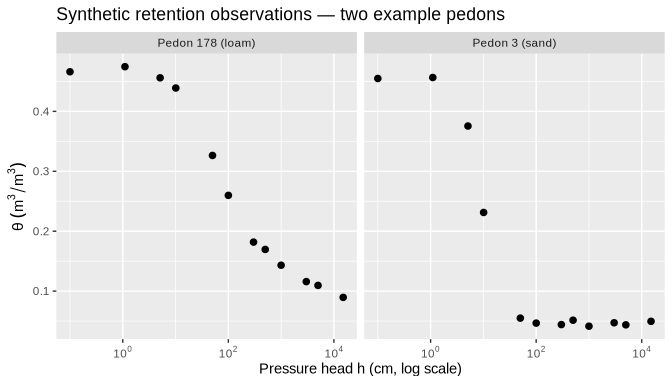

```r
filter(obs_data, pedon_id %in% c(3, 178)) |>
  mutate(label = paste0("Pedon ", pedon_id, " (", texture, ")")) |>
  ggplot(aes(h + 0.1, theta)) +
  geom_point(size = 2) +
  scale_x_log10(labels = scales::label_log()) +
  facet_wrap(~label) +
  labs(
    x = "Pressure head h (cm, log scale)",
    y = expression(theta~(m^3/m^3)),
    title = "Synthetic retention observations — two example pedons"
  )
```